# 18_A_ESmoothing_Trended_Seasonal

```r
library(fpp3)
```

```r
library(patchwork) # to place two plots side by side with p1 + p2
```

# References

1. Hyndman, R.J., & Athanasopoulos, G. (2021). *Forecasting: principles and practice* (3rd ed.). https://otexts.com/fpp3/
2. Fable package documentation. Retrieved from:
   - https://fable.tidyverts.org/index.html and
   - https://fable.tidyverts.org/articles/fable.html
3. Hyndman, R. J., Koehler, A. B., Ord, J. K., & Snyder, R. D. (2008). *Forecasting with exponential smoothing: The state space approach*. Springer-Verlag.

# Note

This notebook is not original material, but rather based on ref. 1 with notes expanding on some of the concepts contained in the book.

# Motivation

Holt-Winters extends Holt’s method to capture seasonality. It has a **forecast equation** and **three smoothing equations**, one per component:

- The **level** $l_t$ (parameter $\alpha$)
- The **trend** $b_t$ (parameter $\beta^*$)
- The **seasonal component** $s_t$ (parameter $\gamma$)

The symbol $m$ is the **length of the seasonal period**: the number of observations per year (or per cycle). For quarterly data $m = 4$, for monthly data $m = 12$.

# Additive vs multiplicative

The method has two variants.

## Additive

- The **additive** method is preferred when the seasonal swings **do not change in proportion to the level of the series.**
  - The **seasonal component** is in **absolute terms**, in the **units of the series**.
  - In the level equation the series is **seasonally adjusted** by **subtracting the seasonal component**.
  - Over a year the seasonal component adds up to about zero (see the session on classical decomposition from scratch):

$$\begin{align*}
\text{For additive seasonal ETS:} && \sum_{i=1}^{m} s_i \approx 0
\end{align*}$$
As a result, the seasonal component does not contribute to the average of the time series over one period.

## Multiplicative

- The **multiplicative method** is preferred when the **seasonal swings change in proportion to the level of the series**.
  - The **seasonal component** is in relative terms (a factor, read as a percentage).
  - In the level equation the series is **seasonally adjusted** by **dividing by the seasonal component**.
  - Over a year the seasonal component adds up to about $m$ (see the session on classical decomposition from scratch).

$$\begin{align*}
\text{For multiplicative seasonal ETS:} && \sum_{i=1}^{m} s_i \approx m
\end{align*}$$

# Holt-Winters’ additive method

## Component form of the equations

As for Holt’s method, we take the equations as given and interpret them below. For a derivation, see reference 3.

**Differences from trended exponential smoothing**:

- A new component, the **seasonal index $s_t$**,
  - with its own **equation**,
  - and its own smoothing parameter $\gamma$.

**Component form equations**:

$$\begin{align*}
\text{Forecast equation}&& \hat{y}_{t+h|t} &= \ell_{t} + hb_{t} + s_{t+h-m(k+1)} \\
\text{Level equation}&& \ell_{t} &= \alpha(y_{t} - s_{t-m}) + (1 - \alpha)(\ell_{t-1} + b_{t-1})\\
\text{Trend equation}&& b_{t} &= \beta^*(\ell_{t} - \ell_{t-1}) + (1 - \beta^*)b_{t-1}\\
\text{Seasonal equation}&& s_{t} &= \gamma (y_{t}-\ell_{t-1}-b_{t-1}) + (1-\gamma)s_{t-m},
\end{align*}$$

## The $k$ subindex in the seasonal component

The subindex $k = int(\frac{h-1}{m})$ can be confusing.

- $int()$ is the *integer part*: it drops everything after the decimal point. For example:
  - int(0.1) = 0
  - int(1.182341) = 1
  - int(2.154) = 2
  - …
- $h$ is the forecast horizon.
- $m$ is the length of the seasonal period. Some examples:
  - For quarterly data and a seasonal period of 1 year: $m=4$
  - For monthly data and a seasonal period of 1 year: $m=12$
  - For daily data and a seasonal period of 1 week: $m=7$
  - For weekly data and a seasonal period of 1 year: $m=52$
  - …

The figure below shows what $k = int(\frac{h-1}{m})$ does. $k$ is the **number of complete years between the last observed year and the forecast**, so that $s_{T+h-m(k+1)}$ always picks the seasonal index of the same season in the **last observed year**. The figure uses $m=12$ (monthly data, yearly season):

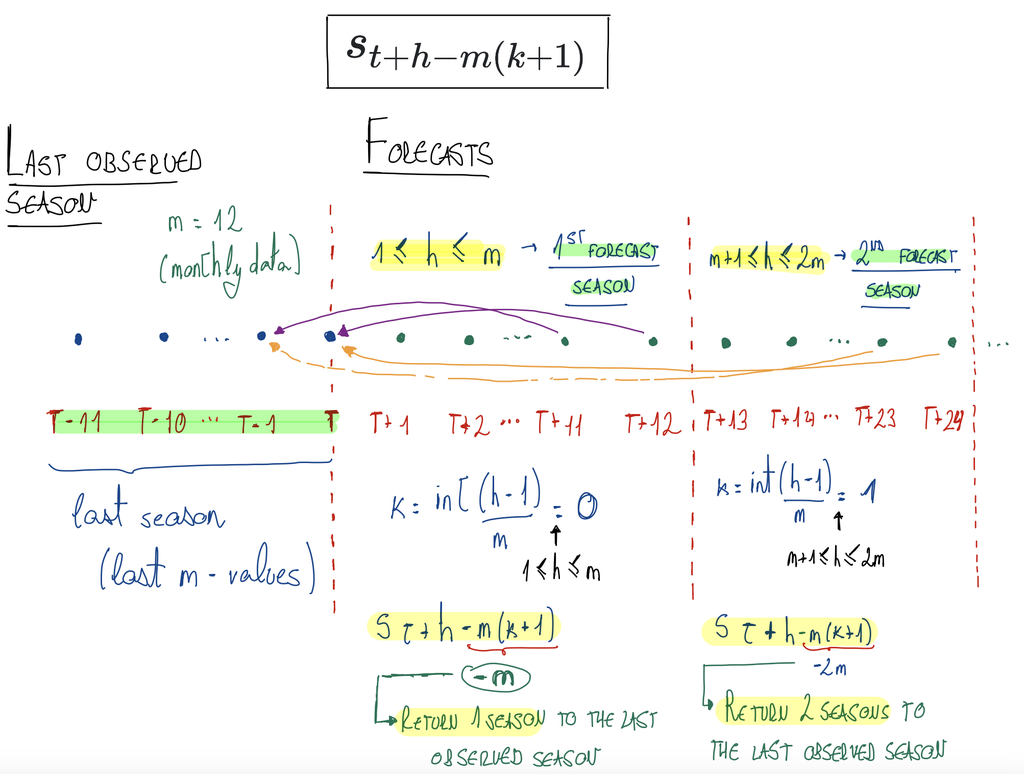

## Equations for the fitted values

To see how these equations fit a series with trend and seasonality, set $h=1$ in the forecast equation (fitted values are one-step-ahead forecasts on the training data), then shift it from $t+1$ to $t$ so that it lines up with the other equations.

- **NOTE** for $h=1$ we have $k=int(\frac{h-1}{m}) = 0$. This is also considered in the equation below

$$\begin{align*}
\text{Forecast equation for h = 1} && \hat{y}_{t+1|t} &= \ell_{t} + 1\cdot b_{t} + s_{t+1-m} \\
\text{Particularize for t instead t+1} && \hat{y}_{t|t-1} &= \ell_{t-1} + 1\cdot b_{t-1} + s_{t-m} && (\text{fitted value at t})\\
\end{align*}$$

Therefore, the **equations for the fitted values are:**

$$\begin{align*}
\text{Fitted value at t} && \hat{y}_{t|t-1} &= \ell_{t-1} + b_{t-1} + s_{t-m} \\
\text{Level equation}&& \ell_{t} &= \alpha(y_{t} - s_{t-m}) + (1 - \alpha)(\ell_{t-1} + b_{t-1})\\
\text{Trend equation}&& b_{t} &= \beta^*(\ell_{t} - \ell_{t-1}) + (1 - \beta^*)b_{t-1}\\
\text{Seasonal equation}&& s_{t} &= \gamma (y_{t}-\ell_{t-1}-b_{t-1}) + (1-\gamma)s_{t-m},
\end{align*}$$

**These equations give the fitted values, given**:

1. The values of the smoothing parameters $\alpha$, $\beta^*$ and $\gamma$
2. An initial value for the level $l_{0}$
3. An initial value for the trend $b_{0}$
4. Initial values for the **seasonal indices of a whole first year:** $(s_0, s_{-1}, s_{-2}, \dots, s_{1-m})$
   - That is $m$ seasonal indices, all given as starting values.
   - The workbook `18_B`, on quarterly data, shows this layout.

**With these, the fitted values are computed as follows:**

- For $t = 1$:
  1. $\hat{y}_{1|0} = \ell_{0} + b_{0} + s_{1-m}$
  2. $l_{1} = \alpha(y_{1}-s_{1-m}) + (1 - \alpha)(l_{0} + b_{0})$
     - The value of $l_1$ is used in the trend equation next.
  3. $b_{1} = \beta^*(l_{1} - l_{0}) + (1 -\beta^*)b_{0}$
  4. $s_1 = \gamma(y_1-l_{0}-b_{0})+(1-\gamma)s_{1-m}$
- For $t = 2$: we proceed in the same manner after having computed $l_1$, $b_1$, and $s_1$ in the previous step.
- For $t = 3$: we proceed in the same manner after having computed $l_2$, $b_2$, and $s_2$ in the previous step.
- …

### Interpreting the equations

A brief interpretation:

#### Level equation

A weighted average of the seasonally adjusted observation and the non-seasonal forecast:

$$\begin{align*}
l_{t} &= \alpha\underbrace{(y_{t} - s_{t-m})}_{\substack{\textrm{seasonally adjusted} \\ \textrm{observation}}} + (1 - \alpha)\underbrace{(\ell_{t-1} + b_{t-1})}_\textrm{non seasonal forecast}\\
\end{align*}$$

#### Trend equation

Identical to Holt’s linear method; see the previous session.

$$\begin{align*}
\text{Trend equation} && b_{t} &= \beta^*\underbrace{(\ell_{t} - \ell_{t-1})}_{\substack{\textrm{estimated trend} \\ \textrm{at time t}}} + (1 -\beta^*)\underbrace{b_{t-1}}_{\substack{\textrm{previous} \\ \textrm{estimate} \\ \textrm{of the trend}}},
\end{align*}$$

- **NOTE:** $\ell_{t} - \ell_{t-1}$ estimates the trend: if the level estimates the series, the difference between consecutive levels, over the one step between them, estimates the slope at time $t$. The figure below shows this:

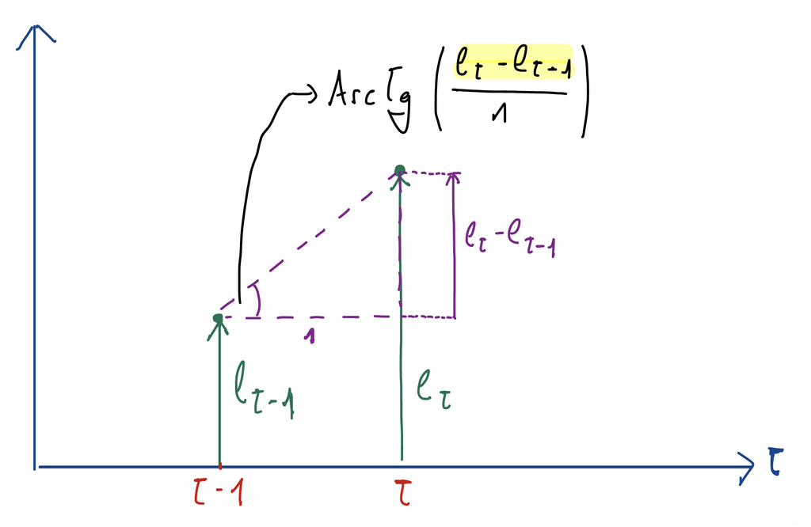

#### The seasonal equation

A weighted average of an estimate of the current seasonal index and the index of the same season one year earlier ($m$ periods ago).

$$\begin{align*}
s_{t} &= \gamma \underbrace{(y_{t}-\ell_{t-1}-b_{t-1})}_{\substack{\textrm{estimate of} \\ \textrm{current seasonal index}}} + (1-\gamma)\underbrace{s_{t-m}}_{\substack{\textrm{seasonal index} \\ \textrm{of the} \\ \textrm{same season} \\ \textrm{last year}}}
\end{align*}$$

- **NOTE:** $y_{t}-\ell_{t-1}-b_{t-1}$ estimates the current seasonal index: it is the observation with the level and slope of the previous step taken away.

#### Fitted value equation

The fitted value at $t$ is Holt’s, plus the seasonal index of the same season one year earlier, $s_{t-m}$.

$$\begin{align*}
\text{Fitted value at t} && \hat{y}_{t|t-1} &= \ell_{t-1} + 1 \cdot b_{t-1} + s_{t-m} \\
\end{align*}$$

## Equation for the forecasts

Once the fitted values, levels $l_t$, slopes $b_t$ and seasonal indices $s_t$ have been computed for every $t$ in the training data (from $t=1$ to $t=T$), the forecasts beyond it are:

$$\begin{align*}
\text{Forecast equation} && \hat{y}_{T+h|T} &= \ell_{T} + hb_{T} + s_{T+h-m(k+1)}
\end{align*}$$

- where $t=T$ is **the last point in time of the training data**.
- $k = int(\frac{h-1}{m})$. See the previous sections for the interpretation of $k$.

Only the last level $l_T$, the last slope $b_T$ and the last year of seasonal indices enter the forecasts.

The h-step forecast is the last level, plus h times the last slope, plus the seasonal index of the same season in the last observed year.

# Holt-Winters’ multiplicative method

In the multiplicative variant:

1. The level $l_t$ and the trend $b_t$ relate in an **additive manner**.
2. The seasonal index $s_{t+h-m(k+1)}$ relates in a multiplicative manner with them both.

The equations are those of the additive method, with the seasonal indices multiplying where they used to add and dividing where they used to subtract:

$$\begin{align*}
\hat{y}_{t+h|t} &= (\ell_{t} + hb_{t})s_{t+h-m(k+1)} \\
\ell_{t} &= \alpha \frac{y_{t}}{s_{t-m}} + (1 - \alpha)(\ell_{t-1} + b_{t-1})\\
b_{t} &= \beta^*(\ell_{t}-\ell_{t-1}) + (1 - \beta^*)b_{t-1} \\
s_{t} &= \gamma \frac{y_{t}}{(\ell_{t-1} + b_{t-1})} + (1 - \gamma)s_{t-m}.
\end{align*}$$

The equation for the fitted values is obtained just as for the additive method:

1. Particularize the forecast equation for $h=1$.
2. Particularize the result at $t$ instead of $t+1$

This notebook does not do it; try it as an exercise, and check it against the multiplicative table in the next section.

# Fitting the models

Fitting Holt-Winters follows the same process: minimize the sum of squared residuals (SSE). We do not implement it from scratch; understanding the process is enough.

Importantly, the search now needs starting values for a whole year of seasonal indices, which adds many parameters.

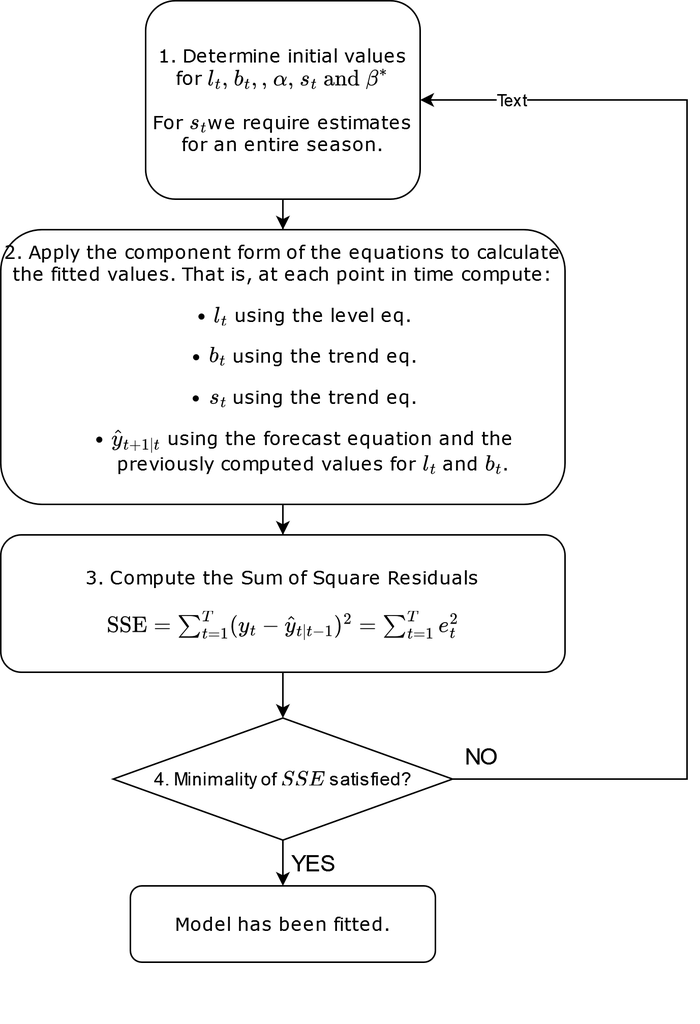

## Example for the additive case

The table below computes the fitted values of **Holt-Winters’ additive method** for the Australian holiday trips of the R example, with $\alpha = 0.262$, $\beta^* = 0.1646$ and $\gamma = 0.0001$. It needs these starting values:

- The level $l_0$: about the average of the first year, 9.8.
- The slope $b_0$: the first year shows no trend, so 0.
- With $m=4$, four seasonal indices for the year before the data: $s_{-3}, s_{-2}, s_{-1}, s_0$.
  - **NOTE:** one way to get them is the first four values of the seasonal component of an additive classical decomposition.
  - **NOTE:** monthly data would need 12, and longer seasonal periods more still.

| Quarter | Time | Observation | Level | Slope | Season | Fitted |
| --- | --- | --- | --- | --- | --- | --- |
|  | t | $y_t$ | $l_t$ | $b_t$ | $s_t$ | $\hat{y}_{t\|t-1}$ |
| 1997 Q1 | -3 |  |  |  | 1.5 |  |
| 1997 Q2 | -2 |  |  |  | -0.3 |  |
| 1997 Q3 | -1 |  |  |  | -0.7 |  |
| 1997 Q4 | 0 |  | 9.8 | 0.0 | -0.5 |  |
| 1998 Q1 | 1 | 11.8 | 9.9 | 0.0 | 1.5 | 11.3 |
| 1998 Q2 | 2 | 9.3 | 9.9 | 0.0 | -0.3 | 9.7 |
| 1998 Q3 | 3 | 8.6 | 9.7 | -0.0 | -0.7 | 9.2 |
| 1998 Q4 | 4 | 9.3 | 9.8 | 0.0 | -0.5 | 9.2 |
|  | … | … | … | … | … | … |
| 2017 Q1 | 77 | 12.4 | 10.9 | 0.1 | 1.5 | 12.3 |
| 2017 Q2 | 78 | 10.5 | 10.9 | 0.1 | -0.3 | 10.7 |
| 2017 Q3 | 79 | 10.5 | 11.0 | 0.1 | -0.7 | 10.3 |
| 2017 Q4 | 80 | 11.2 | 11.3 | 0.1 | -0.5 | 10.6 |
|  | $h$ |  |  |  |  | $\hat{y}_{T+h\|T}$ |
| 2018 Q1 | 1 |  |  |  |  | 12.9 |
| 2018 Q2 | 2 |  |  |  |  | 11.2 |
| 2018 Q3 | 3 |  |  |  |  | 11.0 |
| 2018 Q4 | 4 |  |  |  |  | 11.2 |
| 2019 Q1 | 5 |  |  |  |  | 13.4 |
| 2019 Q2 | 6 |  |  |  |  | 11.7 |
| 2019 Q3 | 7 |  |  |  |  | 11.5 |
| 2019 Q4 | 8 |  |  |  |  | 11.7 |
| 2020 Q1 | 9 |  |  |  |  | 13.9 |
| 2020 Q2 | 10 |  |  |  |  | 12.2 |
| 2020 Q3 | 11 |  |  |  |  | 11.9 |
| 2020 Q4 | 12 |  |  |  |  | 12.2 |

## Example for multiplicative case

The table below computes the fitted values of **Holt-Winters’ multiplicative method** on the same data. Starting values:

- The level $l_0$: about the average of the first year.
- The slope $b_0$: about 0, as before.
- Four seasonal factors for the year before the data.
  - **NOTE:** one way to get them is the first four values of the seasonal component of a multiplicative classical decomposition.

| Quarter | Time | Observation | Level | Slope | Season | Forecast |
| --- | --- | --- | --- | --- | --- | --- |
|  | $t$ | $y_t$ | $l_t$ | $b_t$ | $s_t$ | $\hat{y}_{t\|t-1}$ |
| 1997 Q1 | -3 |  |  |  | 1.2 |  |
| 1997 Q2 | -2 |  |  |  | 1.0 |  |
| 1997 Q3 | -1 |  |  |  | 0.9 |  |
| 1997 Q4 | 0 |  | 10.0 | -0.0 | 0.9 |  |
| 1998 Q1 | 1 | 11.8 | 10.0 | -0.0 | 1.2 | 11.6 |
| 1998 Q2 | 2 | 9.3 | 9.9 | -0.0 | 1.0 | 9.7 |
| 1998 Q3 | 3 | 8.6 | 9.8 | -0.0 | 0.9 | 9.2 |
| 1998 Q4 | 4 | 9.3 | 9.8 | -0.0 | 0.9 | 9.2 |
|  | … | … | … | … | … | … |
| 2017 Q1 | 77 | 12.4 | 10.8 | 0.1 | 1.2 | 12.6 |
| 2017 Q2 | 78 | 10.5 | 10.9 | 0.1 | 1.0 | 10.6 |
| 2017 Q3 | 79 | 10.5 | 11.1 | 0.1 | 0.9 | 10.2 |
| 2017 Q4 | 80 | 11.2 | 11.3 | 0.1 | 0.9 | 10.5 |
|  | $h$ |  |  |  |  | $\hat{y}_{T+h\vert T}$ |
| 2018 Q1 | 1 |  |  |  |  | 13.3 |
| 2018 Q2 | 2 |  |  |  |  | 11.2 |
| 2018 Q3 | 3 |  |  |  |  | 10.8 |
| 2018 Q4 | 4 |  |  |  |  | 11.1 |
| 2019 Q1 | 5 |  |  |  |  | 13.8 |
| 2019 Q2 | 6 |  |  |  |  | 11.7 |
| 2019 Q3 | 7 |  |  |  |  | 11.3 |
| 2019 Q4 | 8 |  |  |  |  | 11.6 |
| 2020 Q1 | 9 |  |  |  |  | 14.4 |
| 2020 Q2 | 10 |  |  |  |  | 12.2 |
| 2020 Q3 | 11 |  |  |  |  | 11.7 |
| 2020 Q4 | 12 |  |  |  |  | 12.1 |

## Exercise: reproduce the additive table in Excel

The workbook `18_B` in this session’s folder has the template for the additive table. Filling it in is part of the homework.

# R example: domestic overnight trips in Australia

## Model specification for Holt-Winters with additive seasonality

In the ETS() formula:

- Specify `error("A")` (additive errors)
- Specify `trend("A")`
- Specify `season("A")`

`ETS(VARIABLE ~ error("A") + trend("A") + season("A"))`

## Model specification for Holt-Winters with multiplicative seasonality

In the ETS() formula:

- Specify `error("M")` (multiplicative errors)
- Specify `trend("A")`
- Specify `season("M")`

`ETS(VARIABLE ~ error("M") + trend("A") + season("M"))`

**Note:** with `season("M")`, use `error("M")` as well. The combination of additive errors with multiplicative seasonality is numerically unstable; the session on the ETS taxonomy lists the excluded combinations.

## Code

Consider the total number of domestic overnight trips in Australia for the purpose “Holiday”. We fit both Holt-Winters’ additive and multiplicative methods to it.

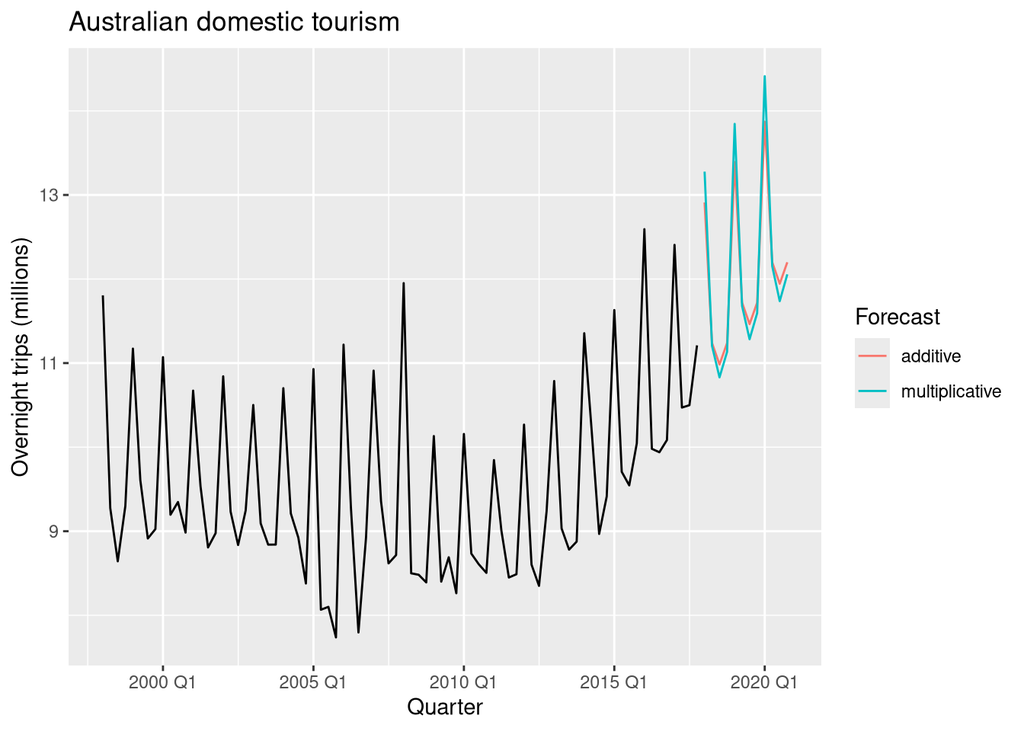

```r
# Filter data
aus_holidays <- tourism |>
  filter(Purpose == "Holiday") |>
  summarise(Trips = sum(Trips)/1e3)

# Fit the models: additive and multiplicative seasonality
# Pay attention to the error terms! (for numerical stability):
  # error("A") for the additive model.
  # error("M") for the multiplicative model.
fit <- aus_holidays |>
  model(
    additive = ETS(Trips ~ error("A") + trend("A") + season("A")),
    multiplicative = ETS(Trips ~ error("M") + trend("A") + season("M"))
  )

# Generate forecasts
fc <- fit |> forecast(h = "3 years")

# Plot the forecasts
fc |>
  autoplot(aus_holidays, level = NULL) +
  labs(title="Australian domestic tourism",
       y="Overnight trips (millions)") +
  guides(colour = guide_legend(title = "Forecast"))
```

Comparing the training accuracy, the multiplicative model has a slightly smaller residual RMSE (a better fit), but the difference is small. (RMSE is from the session on point forecast accuracy.)

```r
fit |> accuracy() |> select(.model, RMSE) |> mutate(RMSE = round(RMSE, 4))
```

```
# A tibble: 2 × 2
  .model          RMSE
  <chr>          <dbl>
1 additive       0.417
2 multiplicative 0.412
```

We can plot the components of each fitted model:

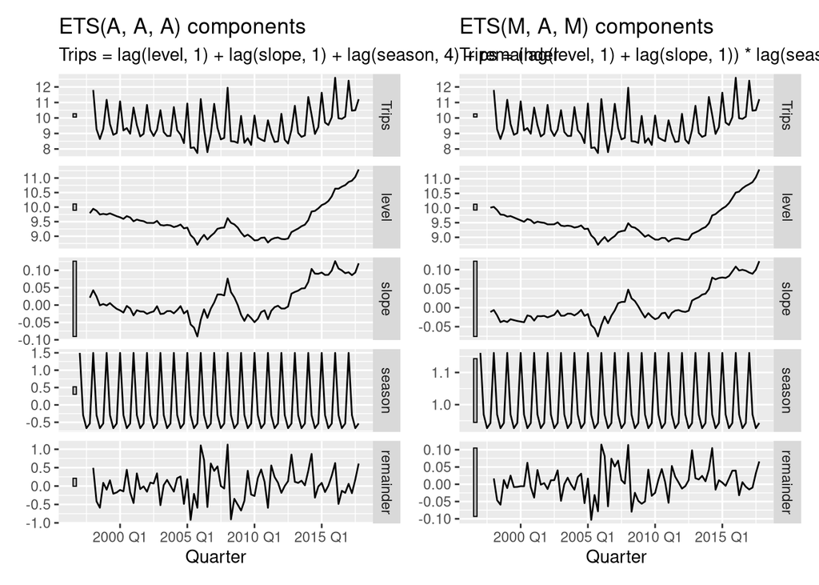

```r
fig_additive <- fit |>
  select("additive") |>
  components() |>
  autoplot() +
  labs(title = "ETS(A, A, A) components")

fig_multiplicative <- fit |>
  select("multiplicative") |>
  components() |>
  autoplot() +
  labs(title = "ETS(M, A, M) components")

# Used patchwork library syntax to organize plots
fig_additive + fig_multiplicative
```

These models already have many parameters, because every starting value is a parameter too. `tidy()` lists them:

```r
fit |> tidy()
```

```
# A tibble: 18 × 3
   .model         term   estimate
   <chr>          <chr>     <dbl>
 1 additive       alpha  0.262
 2 additive       beta   0.0431
 3 additive       gamma  0.000100
 4 additive       l[0]   9.79
 5 additive       b[0]   0.0211
 6 additive       s[0]  -0.534
 7 additive       s[-1] -0.670
 8 additive       s[-2] -0.294
 9 additive       s[-3]  1.50
10 multiplicative alpha  0.224
11 multiplicative beta   0.0304
12 multiplicative gamma  0.000100
13 multiplicative l[0]  10.0
14 multiplicative b[0]  -0.0114
15 multiplicative s[0]   0.943
16 multiplicative s[-1]  0.927
17 multiplicative s[-2]  0.969
18 multiplicative s[-3]  1.16
```

- The small $\gamma$ in both models means that the seasonal pattern barely changes over time.
- The small `beta` means that the slope barely changes. Note that `tidy()` reports `beta` = $\alpha\beta^*$, not $\beta^*$: for the additive model, `beta` = 0.043 and $\beta^*$ = 0.043 / 0.262 = 0.165, the value in the workbook `18_B`.
- 3 smoothing parameters: $\alpha$, $\beta^*$, and $\gamma$.
- 6 initial estimates (1 for the level $l_0$, one for the trend $b_0$, and 4 for the seasonal component $s_{-3}, s_{-2}, ..., s_{0}$). If the data were monthly we would require 12 estimates. For longer seasonal periods (e.g., weekly data with yearly seasonality) the problem becomes substantially more complex.

Recall the famous quote by the great mathematician John von Neumann:

*“With four parameters I can fit an elephant, and with five I can make him wiggle his trunk”* (John von Neumann, as quoted by Enrico Fermi; told by Freeman Dyson in *Nature* 427, 2004).

# Holt-Winters damped method

Often the single most accurate method for seasonal data: the multiplicative method with a damped trend, damped exactly as in the previous session.

$$\begin{align*}
\hat{y}_{t+h|t} &= \left[\ell_{t} + (\phi+\phi^2 + \dots + \phi^{h})b_{t}\right]s_{t+h-m(k+1)} \\
\ell_{t} &= \alpha(y_{t} / s_{t-m}) + (1 - \alpha)(\ell_{t-1} + \phi b_{t-1})\\
b_{t} &= \beta^*(\ell_{t} - \ell_{t-1}) + (1 - \beta^*)\phi b_{t-1} \\
s_{t} &= \gamma \frac{y_{t}}{(\ell_{t-1} + \phi b_{t-1})} + (1 - \gamma)s_{t-m}.
\end{align*}$$

## Model specification for a damped Holt-Winters model

Holt-Winters can be damped in both its additive and multiplicative forms. With multiplicative seasonality it is often hard to beat, and simpler than many models that do not beat it.

In the ETS() formula:

- Specify `error("M")`
- Specify `trend("Ad")`
- Specify `season("M")`

`ETS(VARIABLE ~ error("M") + trend("Ad") + season("M"))`

## R example with daily data

- m = 7 (seasonal period, 1 week)

```r
sth_cross_ped <- pedestrian |>
  filter(Date >= "2016-07-01",
         Sensor == "Southern Cross Station") |>
  index_by(Date) |>
  summarise(Count = sum(Count)/1000)

sth_cross_ped
```

```
# A tsibble: 184 x 2 [1D]
   Date       Count
   <date>     <dbl>
 1 2016-07-01 17.6
 2 2016-07-02  2.52
 3 2016-07-03  1.73
 4 2016-07-04 17.3
 5 2016-07-05 16.5
 6 2016-07-06 16.8
 7 2016-07-07 17.0
 8 2016-07-08 17.2
 9 2016-07-09  3.21
10 2016-07-10  1.75
# ℹ 174 more rows
```

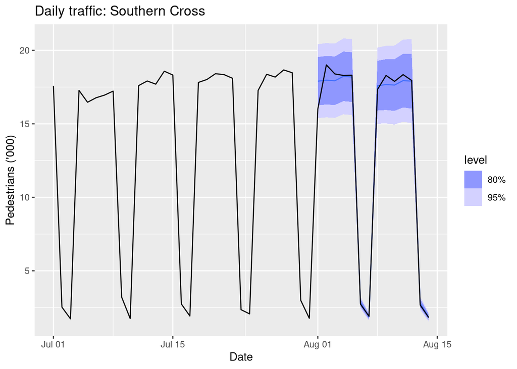

```r
fit <- sth_cross_ped |>
  filter(Date <= "2016-07-31") |>
  model(
    hw = ETS(Count ~ error("M") + trend("Ad") + season("M"))
  )

fc <- fit |>
  forecast(h = "2 weeks")

fc |>
  autoplot(sth_cross_ped |> filter(Date <= "2016-08-14")) +
  labs(title = "Daily traffic: Southern Cross",
       y="Pedestrians ('000)")
```

The model has picked up the weekly pattern and the rising trend at the end of the data.

The forecasts match the two held-out weeks closely.

# Exercise: seasonal exponential smoothing

Use the quarterly number of arrivals to Australia from New Zealand, 1981 Q1 to 2012 Q3, from the dataset `aus_arrivals`.

```
Plot variable not specified, automatically selected `.vars = Arrivals`
```

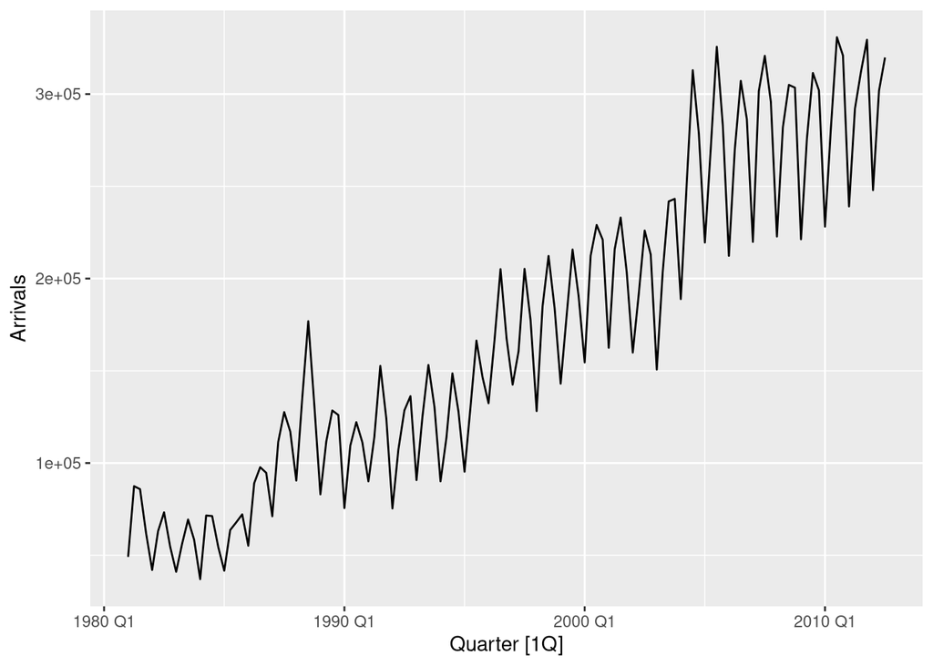

```r
nz_arrivals <- aus_arrivals |> filter(Origin == "NZ")
nz_arrivals |> autoplot()
```

## 1. Time plot

Make a time plot, with a grid that makes the yearly seasonality easy to see.

### We’ll discuss potential solutions during the live session.

Would you say that multiplicative seasonality is necessary?

## 2. Fit models to a training dataset

The code below leaves out the last 8 observations of `nz_arrivals`: the **training dataset** `nz_tr`.

```r
nz_tr <- nz_arrivals |>
  slice(1:(n() - 8))
```

Fit the following models to `nz_tr`:

1. Holt-Winters with additive seasonality. Call it `hw_additive`.
2. Holt-Winters with multiplicative seasonality. Call it `hw_multiplicative`.
3. Holt-Winters with a damped trend and multiplicative seasonality. Call it `hw_multiplicative_damped`.

### We’ll discuss potential solutions during the live session.

## 3. Forecast 8 steps ahead

### We’ll discuss potential solutions during the live session.

## 4. Graphs for the forecasts

Create the following graphs:

1. The forecasts of all the models, with the historical series, without prediction intervals.

### We’ll discuss potential solutions during the live session.

2. The forecasts of the multiplicative method, with the historical series and the prediction intervals.
3. The same for the additive method.
4. The same for the damped multiplicative method.
5. Compute the accuracy of the three models on the 8 held-out quarters, with `accuracy()` and the full series. Which model forecast best, by RMSE? Does that agree with your answer to question 1?
6. What do you conclude?

## Questions on cross-validation

Use cross-validation to compare the models below, with forecasts up to 10 steps ahead:

- a seasonal naïve method, as the benchmark. Call it `snaive`.
- an ETS model fitted to the data without transformation. It must include an additive trend and appropriate seasonality. Call this model `ETS_original`.
- an ETS model fitted to the data without transformation. It must include an additive damped trend and appropriate seasonality. Call this model `ETS_original_Ad`.
- an ETS model fitted to the log-transformed data. It must include an additive trend and appropriate seasonality. Call this model `ETS_original_log`.
- an ETS model fitted to the log-transformed data. It must include an additive damped trend and appropriate seasonality. Call this model `ETS_original_Ad_log`.
- a `decomposition_model()` that applies a default STL decomposition to the data and then uses:
  - a trended ETS for the seasonality adjusted data (only trend and no seasonality).
  - a seasonal ETS model for the seasonal component (only seasonality, no trend).
  - call this model `dcmp_ETS`

The smallest training set has 80% of the observations, and the sets grow one observation at a time.

### 5. Create the training datasets using `stretch_tsibble`:

Apply `stretch_tsibble` to `nz_arrivals`

#### We’ll discuss potential solutions during the live session.

### 6. Fit the models to the training datasets

#### We’ll discuss potential solutions during the live session.

### 7. Forecast and label horizons

Forecast up to 10 steps ahead. Add a column `h` with the horizon of each forecast, and make sure the result is still a fable (see the session on cross-validation).

#### We’ll discuss potential solutions during the live session.

### 8. Cross-validated accuracy

Compute the cross-validated accuracy metrics for each model, averaged over all forecast horizons.

Interpret the MAE of the best model.

#### We’ll discuss potential solutions during the live session.

### 9. Best model by forecast horizon

Compute the cross-validated accuracy metrics for each model and forecast horizon.

Then build a table with only the best model by RMSE at each forecast horizon.

Finally, plot which model is best at each horizon by RMSE.

#### We’ll discuss potential solutions during the live session.

### 10. Residual diagnostics of the best model

Take the best model on average over all horizons, fit it to the whole series and analyze its residuals.

#### We’ll discuss potential solutions during the live session.